# ST 431/531: Sampling Methods

Two Phase Sampling | Unequal Probability Sampling

Week 7

## Outline

- Two-Phase Sampling
  - Introduction
  - Two-Phase vs. Two-Stage
  - Estimators
  - Example
- Sampling with Unequal Probabilities
  - Introduction
  - Sampling One PSU

# Two-Phase Sampling

## Two-Phase Sampling (*Lohr* Chapter 12)

If the sampling frame lacks information on auxiliary variables (to form strata, to use for ratio estimation), you can use **two-phase sampling** (also called **double sampling**).

Can be useful:

- When variable of interest $y$ is expensive to measure, but correlated variable $x$ can be measured easily and used to improve precision. Information on $x$ not known ahead of time.
- To adjust for non-response.
- To sample rare populations.
- To improve the sampling frame.

## Two-Phase Sampling

#### Procedure:

1. **Phase I**: Take a probability sample of $n^{(1)}$ units. This is called the phase I sample. Measure the auxiliary variables $\mathbf{x}$ for every unit. Generally pretty large because information about $\mathbf{x}$’s is cheap to obtain.
2. **Phase II**: Treat the phase I sample as the population and select a probability sample of size $n^{(2)}$ from the phase I sample. This is called the phase II sample. Measure the variable of interest for the phase II sample, and treat the information from the phase I sample as auxiliary information.

## Example

Two-phase sampling is often used in forestry surveys. Aerial photographs can be inspected to classify grid areas into forest land, unproductive forest land, nonforest land, and water.

A phase I sample is drawn from the grid and examined more closely to classify areas by stand size and density. In the phase II sample, ground measurements such as land use, volume, and mortality are taken.

The percent area that is forest from the phase II sample (ground) may differ somewhat from the phase I sample (photos), so ratio estimation can be used.

## Two-Phase vs. Two-Stage

In a **two-phase** design, the phase I sample is used to collect inexpensive auxiliary information on the sampling units. This information is used to improve the efficiency of the phase II sample design. The units selected in both phases are the same size.

In a **two-stage** design, different sizes of sampling units are collected at the two stages. All psus selected at stage 1 are subsampled. In a two-phase design, some psus samples in the phase I sample may not be in the phase II sample.

## Comments

- Think of $x$ as easy to collect, $y$ as hard to collect
- This is not cluster sampling - sample units are the same size at each phase
- We assume $x$ and $y$ are related
- $n^{(1)}>n^{(2)}$ since the phase II sample is a subset of the phase I sample

## Visual Representation

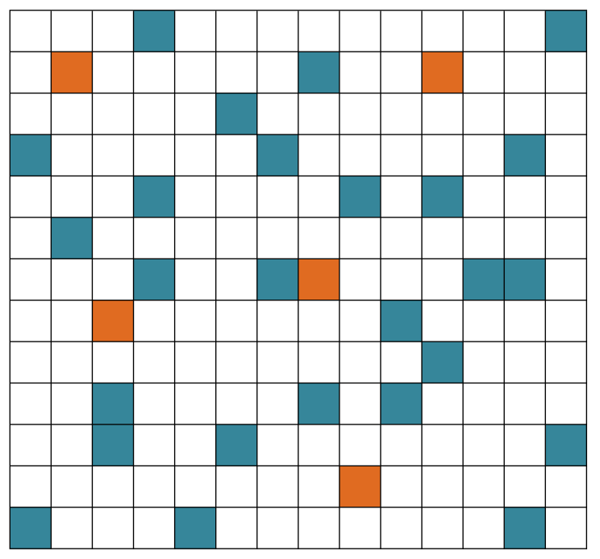

A 13 by 14 grid is shown. Five boxes are shaded in orange, and a further 26 boxes are shaded in blue; the remaining boxes are unshaded. The shaded boxes appear in no particular pattern.

## Ratio Estimation

Let $\mathcal{S}^{(1)}$ be the set of sample units selected in phase I. There are $n^{(1)}$ of these units. Assume SRS.

Let $\mathcal{S}^{(2)}$ be the set of sample units selected in phase II. There are $n^{(2)}$ of these units. Assume SRS.

We observe $x$ on all $n^{(1)}$ units in phase I.

We observe $y$ on all $n^{(2)}$ units in phase II.

## Ratio Estimation

Since we observe $x$ and $y$ on all units in $\mathcal{S}^{(2)}$, we can estimate the ratio:

$$\hat{B}^{(2)}=\frac{\frac{1}{n^{(2)}}\sum_{i\in\mathcal{S}^{(2)}}y_i}{\frac{1}{n^{(2)}}\sum_{i\in\mathcal{S}^{(2)}}x_i}=\frac{\text{sample mean of }y\text{ in phase II}}{\text{sample mean of }x\text{ in phase II}}$$

We don’t know $t_x$ so we can’t estimate $\hat{t}_{yr}^{(2)}=\hat{B}^{(2)}t_x$. But we can estimate $\hat{t}_x$ from the phase I sample.

## Ratio Estimation

Estimating $\hat{t}_x$ from the phase I sample:

$$\hat{t}_x^{(1)}=N\cdot\frac{\sum_{i\in\mathcal{S}^{(1)}}x_i}{n^{(1)}}=N\cdot \text{(sample mean of }x\text{ from phase I)}$$

Then the ratio estimator is:

$$\hat{t}_{yr}^{(2)}=\hat{B}^{(2)}\hat{t}_x^{(1)}$$

## Ratio Estimator Variance

The estimated variance is

$$\hat{V}(\hat{t}_{yr}^{(2)})=\underbrace{N^2\left(1-\frac{n^{(1)}}{N}\right)\frac{s_y^2}{n^{(1)}}}_\text{phase I variance}+\underbrace{N^2\left(1-\frac{n^{(2)}}{n^{(1)}}\right)\frac{s_e^2}{n^{(2)}}}_\text{phase II variance}$$

where

$$\begin{align*}
s_y^2 &= \text{sample variance of }y\text{ in phase II} \\
&= \frac{1}{n^{(2)}-1}\sum_{i\in\mathcal{S}^{(2)}}(y_i-\bar{y}^{(2)})^2 \\
s_e^2 &= \text{sample variance of residuals} \\
&= \frac{1}{n^{(2)}-1}\sum_{i\in\mathcal{S}^{(2)}}(y_i-\hat{B}^{(2)}x_i)^2
\end{align*}$$

## Example

Goal is to measure a population of moose in an area that was divided into 100 equal areas (plots). A total of 240 moose were seen in 20 randomly selected plots using an aerial survey. A sample of 5 of those plots was randomly selected and visited by ground crews. The ground crews found only 56 moose while 70 moose had been discovered by air in those 5 plots.

$$\begin{align*}
y &= \text{actual number of moose detected on ground} \\
x &= \text{number of moose detected by air (auxiliary variable)}
\end{align*}$$

## Example - Data

| Plot | Moose by air ( $x$ ) | Moose by ground ( $y$ ) |
| --- | --- | --- |
| 1 | 10 | 7 |
| 2 | 10 | NA |
| 3 | 15 | NA |
| 4 | 15 | 12 |
| 5 | 11 | NA |
| 6 | 8 | 8 |
| $\vdots$ | $\vdots$ | $\vdots$ |
| 19 | 19 | 14 |
| 20 | 18 | 15 |
| Total | 240 | 56 |

## Example

> Estimate the total number of moose using the auxiliary information:

$$\begin{align*}
\hat{B}^{(2)} &= \frac{\bar{y}^{(2)}}{\bar{x}^{(2)}} = \frac{56/5}{70/5}=0.8 \\
\hat{t}_x^{(1)} &= N \frac{1}{n^{(1)}}\sum_{i\in\mathcal{S}^{(1)}}x_i = 100\frac{1}{20}(240) = 1200 \\
\hat{t}_{yr}^{(2)} &= \hat{B}^{(2)}\hat{t}_x^{(1)} = 0.8(1200) = 960
\end{align*}$$

(If we just observed moose by air, we’d estimate 1200. In the plots we observed on the ground, there were fewer moose than we expected (56 instead of 70), so we scale the estimate down to 960.)

## Example

> Find the standard error of the estimator:

$$\begin{align*}
s_y^2 &= \frac{1}{n^{(2)}-1}\sum_{i\in\mathcal{S}^{(2)}}(y_i-\bar{y}^{(2)})^2 \\
&= \text{variance of } \{7,12,8,14,15\}=12.7 \\
& \\
s_e^2 &= \frac{1}{n^{(2)}-1}\sum_{i\in\mathcal{S}^{(2)}}(y_i-\hat{B}^{(2)}x_i)^2 \\
&= \frac{(7-0.8(10))^2+\cdots+(15-0.8(18))^2}{5-1} = 1.34 \\
\end{align*}$$

## Example

> Find the standard error of the estimator:

$$\begin{align*}
\hat{V}(\hat{t}_{yr}^{(2)}) &= N^2\left(1-\frac{n^{(1)}}{N}\right)\frac{s_y^2}{n^{(1)}}+N^2\left(1-\frac{n^{(2)}}{n^{(1)}}\right)\frac{s_e^2}{n^{(2)}} \\
&= 100^2\left(1-\frac{20}{100}\right)\frac{12.7}{20}+100^2\left(1-\frac{5}{20}\right)\frac{1.34}{5} \\
&= 7090 \\
& \\
\text{SE}(\hat{t}_{yr}^{(2)}) &= \sqrt{7090} = 84.2
\end{align*}$$

## Introduction

Up until now, we’ve looked at designs where sampling within a group was done with **equal probability**.

- SRS
- For stratified sampling, we took a SRS within each strata
- For cluster sampling, we took a SRS of clusters (and for two-stage designs, a SRS of ssus within clusters)
- For systematic sampling, the first unit in $1,\ldots,k$ was selected using a SRS
- For two-phase sampling, each phase was a SRS

## Examples

There are also situations where we may want to sample units with **unequal probabilities**, for example

- Sample cities proportional to their population
- Sample companies proportional to their profits
- Sample farms proportional to acreage
- Sample rivers proportional to width

Sampling with unequal probabilities can provide more precise estimates than a SRS.

## Sampling One PSU

Suppose there are $N$ psus and we want to select just one of them.

Let $\psi_i$ be the probability that unit $i$ is selected on the first draw.

In a SRS of psus, each of the $N$ psus would have chance $\pi_i=\psi_i=1/N$ of being selected.

## Example

Consider a town with four supermarkets, with size (in $\text{m}^2$) as shown in the table below.

| Store | Size ( $\text{m}^2$ ) | $t_i$ (in Thousands) |
| --- | --- | --- |
| A | 100 | 11 |
| B | 200 | 20 |
| C | 300 | 24 |
| D | 1000 | 245 |

Suppose we want to sample one store ( $i$ ) and use its total amount of sales for the last month ( $t_i$ ) to estimate the total in all four stores.

We might expect a larger store to have more sales than a smaller store, and that the variability for larger stores would be greater than the variability for smaller stores.

## Visualization

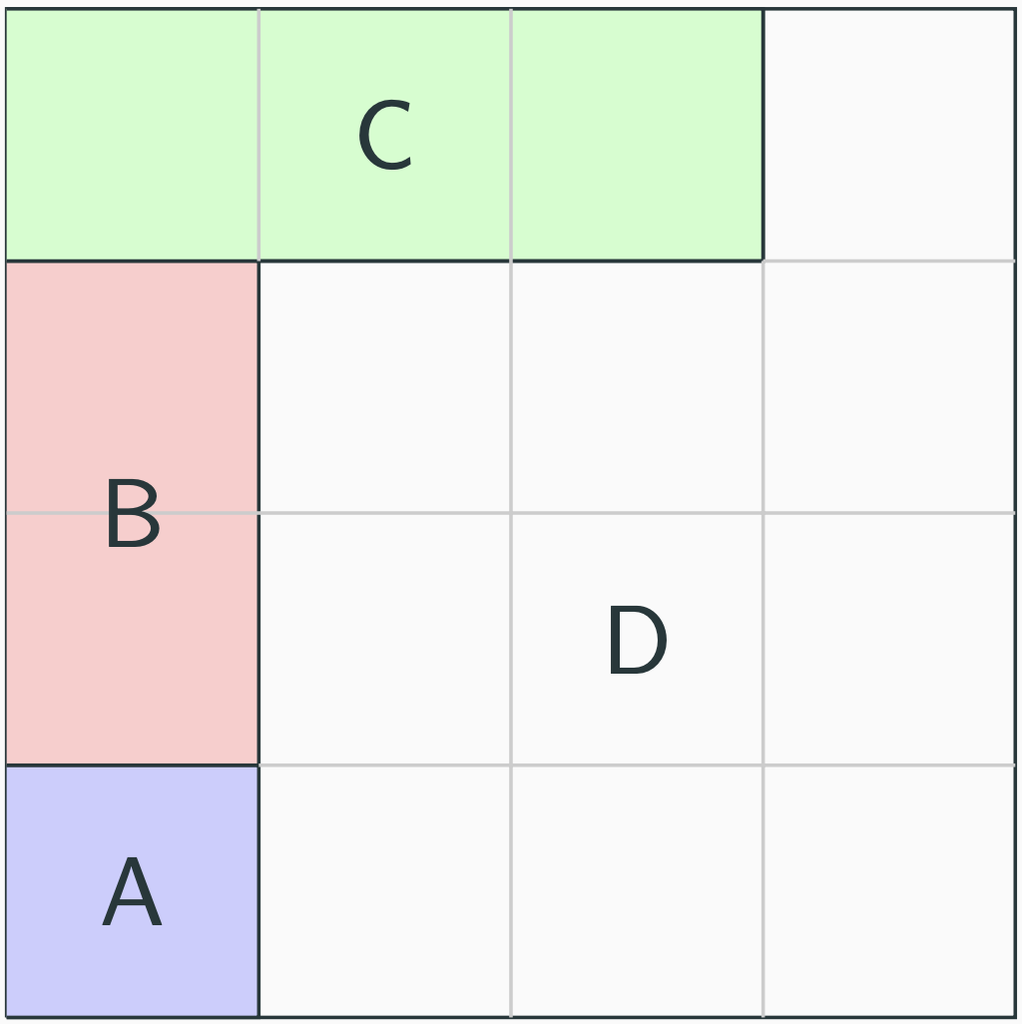

A 4 by 4 grid is shown and divided into four regions. Region A contains 1 grid cell. Region B contains two grid cells. Regio9n C contains 3 grid cells. The remaining 10 grid cells are in Region D.

## Example

Instead of selecting each store with chance $1/4$, consider selecting each store with *probability proportional to its size*.

Overall, there are $100+200+300+1000=1600$ $\text{m}^2$ of space in all stores.

- Store A takes up 100 $\text{m}^2$, so it should have chance $100/1600=1/16$ of being selected.
- Similarly, store D takes up 1000 $\text{m}^2$, so it should have chance $1000/1600=10/16$ of being selected.

## Selection Probability Table

| Store | Size ( $\text{m}^2$ ) | $\psi_i$ | $t_i$ (in Thousands) |
| --- | --- | --- | --- |
| A | 100 | 1/16 | 11 |
| B | 200 | 2/16 | 20 |
| C | 300 | 3/16 | 24 |
| D | 1000 | 10/16 | 245 |

## Sampling Weights

As we’ve seen, the **sampling weight** is the reciprocal of the probability of selection:

$$w_i=\frac{1}{P(\text{unit }i\text{ in sample})}=\frac{1}{\psi_i}$$

## Unequal Probability Sample of Size 1

The estimator for the population total from an unequal-probability sample of size 1 is then
$$\hat{t}_\psi=\sum_{i\in\mathcal{S}}w_it_i=\sum_{i\in\mathcal{S}}\frac{t_i}{\psi_i}$$

## Sampling Distribution

Four possible samples of size 1 are possible from this population of size 4. Let’s find the sampling distribution.

| Sample | $\psi_i$ | $w_i$ | $t_i$ | Estimated pop. total $\hat{t}_\psi$ |
| --- | --- | --- | --- | --- |
| $\{A\}$ | 1/16 | 16 | 11 | 176 |
| $\{B\}$ | 2/16 | 8 | 20 | 160 |
| $\{C\}$ | 3/16 | 16/3 | 24 | 128 |
| $\{D\}$ | 10/16 | 16/10 | 245 | 392 |

- For the sample of store A, $\hat{t}_\psi=w_it_i=16\times 11=176$.
- For the sample of store D, $\hat{t}_\psi=w_it_i=\frac{16}{10}\times 245=392$.

## Expected Value of Sampling Distribution

$$\begin{align*}
E[\hat{t}_\psi]&=\sum_{\text{possible } \mathcal{S}}P(\mathcal{S})\hat{t}_{\psi\mathcal{S}} \\
&= \frac{1}{16}(176)+\frac{2}{16}(160)+\frac{3}{16}(128)+\frac{10}{16}(392) \\
&= 300
\end{align*}$$

$\hat{t}_\psi$ will always be **unbiased** because
$$E[\hat{t}_\psi]=\sum_{i=1}^N\psi_i\frac{t_i}{\psi_i}=\sum_{i=1}^N t_i = t$$

## Variance of Sampling Distribution

The variance of $\hat{t}_\psi$ is

$$\begin{align*}
V[\hat{t}_\psi]&= \sum_{\text{possible }\mathcal{S}}P(\mathcal{S})(\hat{t}_{\psi\mathcal{S}}-t)^2 \\
&= \sum_{i=1}^N \psi_i \left(\frac{t_i}{\psi_i}-t\right)^2 \\
&= \frac{1}{16}\left(176-300\right)^2 + \cdots + \frac{10}{16}\left(392-300\right)^2 \\
&= 14,248
\end{align*}$$

## Comparison to SRS

If we assumed that each store had chance $1/4$ of being selected, we could also find the expected value and variance of this sampling distribution.

| Sample | $P(\mathcal{S})$ | $t_i$ | $\hat{t}_{SRS}=N\times t_i$ |
| --- | --- | --- | --- |
| $\{A\}$ | 1/4 | 11 | 44 |
| $\{B\}$ | 1/4 | 20 | 80 |
| $\{C\}$ | 1/4 | 24 | 96 |
| $\{D\}$ | 1/4 | 245 | 980 |

- $E[\hat{t}_{SRS}]=\frac{44+80+96+980}{4}=300$
- $V[\hat{t}_{SRS}]=\frac{(44-300)^2+(80-300)^2+(96-300)^2+(980-300)^2}{4} = 154,488$

## Comparison to SRS

Both estimators are *unbiased*.

> Why is the SRS variance larger? (154,488 versus 14,248)

The unequal-probability design uses auxiliary information: we expect store size to be related to sales. By using this extra information, we are able to get a more precise estimate.

But, as we have seen, if this auxiliary information is not correlated with our response, we can get worse estimates.

## Comparison to SRS

> What if the sales for stores C and D were actually switched?

| Sample | $\psi_i$ | $w_i$ | $t_i$ | $\hat{t}_\psi$ |
| --- | --- | --- | --- | --- |
| $\{A\}$ | 1/16 | 16 | 11 | 176 |
| $\{B\}$ | 2/16 | 8 | 20 | 160 |
| $\{C\}$ | 3/16 | 16/3 | 245 | 1306.7 |
| $\{D\}$ | 10/16 | 16/10 | 24 | 38.4 |

The SRS sampling distribution expected value and variance will stay the same. So now the unequal-probability design has the larger variance.